# R Programming: Week 4 Assignment

# Intro

This is the hospital assignment. The PDF and dataset are in the data directory of this week. The goal is to sort/arrange/subset/filter a dataset. Let’s begin.

## 1. plot the data

First, we’ll read in the outcome data, then we’ll take a look at a small portion of it.

```r
dir("./data")
```

```
[1] "Hospital_Revised_Flatfiles.pdf" "hospital-data.csv"              "outcome-of-care-measures.csv"
```

```r
outcome <- read.csv(paste0("./data/", dir("./data")[3]), colClasses = "character")
head(outcome)
```

|  | Provider.Number | Hospital.Name | Address.1 | Address.2 | Address.3 | City | State | ZIP.Code | County.Name | Phone.Number | Hospital.30.Day.Death..Mortality..Rates.from.Heart.Attack | Comparison.to.U.S..Rate...Hospital.30.Day.Death..Mortality..Rates.from.Heart.Attack | Lower.Mortality.Estimate...Hospital.30.Day.Death..Mortality..Rates.from.Heart.Attack | Upper.Mortality.Estimate...Hospital.30.Day.Death..Mortality..Rates.from.Heart.Attack | Number.of.Patients...Hospital.30.Day.Death..Mortality..Rates.from.Heart.Attack | Footnote...Hospital.30.Day.Death..Mortality..Rates.from.Heart.Attack | Hospital.30.Day.Death..Mortality..Rates.from.Heart.Failure | Comparison.to.U.S..Rate...Hospital.30.Day.Death..Mortality..Rates.from.Heart.Failure | Lower.Mortality.Estimate...Hospital.30.Day.Death..Mortality..Rates.from.Heart.Failure | Upper.Mortality.Estimate...Hospital.30.Day.Death..Mortality..Rates.from.Heart.Failure | Number.of.Patients...Hospital.30.Day.Death..Mortality..Rates.from.Heart.Failure | Footnote...Hospital.30.Day.Death..Mortality..Rates.from.Heart.Failure | Hospital.30.Day.Death..Mortality..Rates.from.Pneumonia | Comparison.to.U.S..Rate...Hospital.30.Day.Death..Mortality..Rates.from.Pneumonia | Lower.Mortality.Estimate...Hospital.30.Day.Death..Mortality..Rates.from.Pneumonia | Upper.Mortality.Estimate...Hospital.30.Day.Death..Mortality..Rates.from.Pneumonia | Number.of.Patients...Hospital.30.Day.Death..Mortality..Rates.from.Pneumonia | Footnote...Hospital.30.Day.Death..Mortality..Rates.from.Pneumonia | Hospital.30.Day.Readmission.Rates.from.Heart.Attack | … |
| --- | --- | --- | --- | --- | --- | --- | --- | --- | --- | --- | --- | --- | --- | --- | --- | --- | --- | --- | --- | --- | --- | --- | --- | --- | --- | --- | --- | --- | --- | --- |
| 1 | 010001 | SOUTHEAST ALABAMA MEDICAL CENTER | 1108 ROSS CLARK CIRCLE |  |  | DOTHAN | AL | 36301 | HOUSTON | 3347938701 | 14.3 | No Different than U.S. National Rate | 12.1 | 17.0 | 666 |  | 11.4 | No Different than U.S. National Rate | 9.5 | 13.7 | 741 |  | 10.9 | No Different than U.S. National Rate | 8.6 | 13.7 | 371 |  | 19.0 | … |
| 2 | 010005 | MARSHALL MEDICAL CENTER SOUTH | 2505 U S HIGHWAY 431 NORTH |  |  | BOAZ | AL | 35957 | MARSHALL | 2565938310 | 18.5 | No Different than U.S. National Rate | 14.7 | 23.0 | 44 |  | 15.2 | Worse than U.S. National Rate | 12.2 | 18.8 | 234 |  | 13.9 | No Different than U.S. National Rate | 11.3 | 17.0 | 372 |  | Not Available | … |
| 3 | 010006 | ELIZA COFFEE MEMORIAL HOSPITAL | 205 MARENGO STREET |  |  | FLORENCE | AL | 35631 | LAUDERDALE | 2567688400 | 18.1 | No Different than U.S. National Rate | 14.8 | 21.8 | 329 |  | 11.3 | No Different than U.S. National Rate | 9.1 | 13.9 | 523 |  | 13.4 | No Different than U.S. National Rate | 11.2 | 15.8 | 836 |  | 17.8 | … |
| 4 | 010007 | MIZELL MEMORIAL HOSPITAL | 702 N MAIN ST |  |  | OPP | AL | 36467 | COVINGTON | 3344933541 | Not Available | Number of Cases Too Small | Not Available | Not Available | 14 | number of cases is too small (fewer than 25) to reliably tell how well the hospital is performing | 13.6 | No Different than U.S. National Rate | 10.0 | 18.2 | 113 |  | 14.9 | No Different than U.S. National Rate | 11.6 | 19.0 | 239 |  | Not Available | … |
| 5 | 010008 | CRENSHAW COMMUNITY HOSPITAL | 101 HOSPITAL CIRCLE |  |  | LUVERNE | AL | 36049 | CRENSHAW | 3343353374 | Not Available | Number of Cases Too Small | Not Available | Not Available | 9 | number of cases is too small (fewer than 25) to reliably tell how well the hospital is performing | 13.8 | No Different than U.S. National Rate | 9.9 | 18.7 | 53 |  | 15.8 | No Different than U.S. National Rate | 11.4 | 21.5 | 61 |  | Not Available | … |
| 6 | 010010 | MARSHALL MEDICAL CENTER NORTH | 8000 ALABAMA HIGHWAY 69 |  |  | GUNTERSVILLE | AL | 35976 | MARSHALL | 2565718000 | Not Available | Number of Cases Too Small | Not Available | Not Available | 22 | number of cases is too small (fewer than 25) to reliably tell how well the hospital is performing | 12.5 | No Different than U.S. National Rate | 9.9 | 15.6 | 163 |  | 8.7 | Better than U.S. National Rate | 6.8 | 11.0 | 315 |  | Not Available | … |

```r
str(outcome)
```

```
'data.frame':   4706 obs. of  46 variables:
 $ Provider.Number                                                                      : chr  "010001" "010005" "010006" "010007" ...
 $ Hospital.Name                                                                        : chr  "SOUTHEAST ALABAMA MEDICAL CENTER" "MARSHALL MEDICAL CENTER SOUTH" "ELIZA COFFEE MEMORIAL HOSPITAL" "MIZELL MEMORIAL HOSPITAL" ...
 $ Address.1                                                                            : chr  "1108 ROSS CLARK CIRCLE" "2505 U S HIGHWAY 431 NORTH" "205 MARENGO STREET" "702 N MAIN ST" ...
 $ Address.2                                                                            : chr  "" "" "" "" ...
 $ Address.3                                                                            : chr  "" "" "" "" ...
 $ City                                                                                 : chr  "DOTHAN" "BOAZ" "FLORENCE" "OPP" ...
 $ State                                                                                : chr  "AL" "AL" "AL" "AL" ...
 $ ZIP.Code                                                                             : chr  "36301" "35957" "35631" "36467" ...
 $ County.Name                                                                          : chr  "HOUSTON" "MARSHALL" "LAUDERDALE" "COVINGTON" ...
 $ Phone.Number                                                                         : chr  "3347938701" "2565938310" "2567688400" "3344933541" ...
 $ Hospital.30.Day.Death..Mortality..Rates.from.Heart.Attack                            : chr  "14.3" "18.5" "18.1" "Not Available" ...
 $ Comparison.to.U.S..Rate...Hospital.30.Day.Death..Mortality..Rates.from.Heart.Attack  : chr  "No Different than U.S. National Rate" "No Different than U.S. National Rate" "No Different than U.S. National Rate" "Number of Cases Too Small" ...
 $ Lower.Mortality.Estimate...Hospital.30.Day.Death..Mortality..Rates.from.Heart.Attack : chr  "12.1" "14.7" "14.8" "Not Available" ...
 $ Upper.Mortality.Estimate...Hospital.30.Day.Death..Mortality..Rates.from.Heart.Attack : chr  "17.0" "23.0" "21.8" "Not Available" ...
```

[output cut: 32 more lines]

Let’s start with a histogram of the 30 day death rates from heart attacks. The “outcomes” dataset lists > 4000 hospitals, and column 11 is the 30-day risk-adjusted rate for heart attacks. We’ll coerce this column to be numeric and make a histogram.

```r
outcome[, 11] <- as.numeric(outcome[, 11])
```

```
NAs introduced by coercion
```

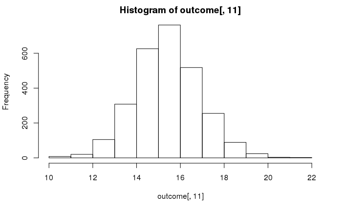

```r
hist(outcome[, 11])
```

## 2. find the best hospital in the state

Now we’ll write a function `best()` that will take a state and outcome name and return the top hospital. Need to return the `Hospital.Name`. Outcome can be either “heart attack”, “heart failure”, or “pneumonia.” Exclude `NA`’s. Return 1st hospital alphabetically in the event of a tie. Here’s the plan:

1. read the .csv
2. pull only relevant columns
3. make list of states (from data)
4. make list of outcomes
5. rename 3 outcomes columns
6. check for valid state and outcome input
7. split the dataset by state
8. order each state subset by hospital name (for ties)
9. use `which.min()` to find the index of the minimum value for this outcome
10. use that index to return the correct hospital name

```r
best <- function(state, outcome) {

     # read the outcome data, cast outcomes as numeric
     all <- read.csv(paste0("./data/", dir("./data")[3]), colClasses = "character")
     data <- all[, c(2, 7, 11, 17, 23)]

     # generate vector of valid states based on state abbrreviations from the data
     # make vector of outcomes
     states <- levels(as.factor(data[, 2]))
     outcomes <- c("heart attack", "heart failure", "pneumonia")

     for (c in 3:5) {
          suppressWarnings(data[, c] <- as.numeric(data[, c]))
          names(data)[c] <- outcomes[c-2]
     }

     # check that the state and outcome inputs are valid
     if (!is.element(outcome, outcomes)) {
          stop("invalid outcome")
     } else if (!is.element(state, states)) {
          stop("invalid state")
     }

     # split data by state; order every data frame in list by hospital name
     data <- lapply(split(data, data$State), function(x) x[order(x$Hospital.Name), ])

     # find index of outcome minimum for each state, then for this state
     indvec <- sapply(data, function(x) which.min(x[[outcome]]))
     ind <- unname(indvec[state])

     # return the hospital name in that state whith the lowest 30-day death rate
     name <- as.vector(data[[state]]$Hospital.Name)[ind]

     name
}
```

Now, we test:

```r
best("TX", "heart attack")
```

```
[1] "CYPRESS FAIRBANKS MEDICAL CENTER"
```

```r
best("TX", "heart failure")
```

```
[1] "FORT DUNCAN MEDICAL CENTER"
```

```r
best("MD", "heart attack")
```

```
[1] "JOHNS HOPKINS HOSPITAL, THE"
```

```r
best("MD", "pneumonia")
```

```
[1] "GREATER BALTIMORE MEDICAL CENTER"
```

```r
best("BB", "heart attack")
```

```
Error in best("BB", "heart attack") : invalid state
```

```r
best("NY", "hert attack")
```

```
Error in best("NY", "hert attack") : invalid outcome
```

## 3. Rank hospitals by outcome in a state

I need to write a function called `rankhospital` that takes 3 args: state, outcome, the ranking of a hospital in that state for that outcome. I need to return the hospital name that has that rank. The rank arg can accept “best” or “worst” as well as integers; return `NA` if the number > # of hospitals in that state. Exclude `NA`’s from rankings. Ties should be broken by hospital name.

Need to check the validity of args.

The plan:

1. if rank is “best”, call `best()`
2. read.csv
3. pull only relevant columns
4. make list of states (from data)
5. make list of outcomes
6. rename 3 outcome columns
7. check for valid state and outcome input
8. if rank is “worst”
   - split data by state, order by outcome (desc) and hospital name (asc)
   - use `which.max` to find the index of the max value for this outcome (spoiler, it’s the 1st in the list, cause we ordered by this)
   - use that index (1) to return hospital name
9. else
   - split data by state, order by outcome (asc)
   - use `num` arg as index to return hospital name

```r
rankhospital <- function(state, outcome, num = "best") {

     if (num == "best") {
          name <- best(state, outcome)
     }

     data <- read.csv(paste0("./data/", dir("./data")[3]), colClasses = "character")
     data <- data[, c(2, 7, 11, 17, 23)]

     states <- levels(as.factor(data[, 2]))
     outcomes <- c("heart attack", "heart failure", "pneumonia")

     for (c in 3:5) {
          suppressWarnings(data[, c] <- as.numeric(data[, c]))
          names(data)[c] <- outcomes[c-2]
     }

     if (!is.element(outcome, outcomes)) {
          stop("invalid outcome")
     } else if (!is.element(state, states)) {
          stop("invalid state")
     }

     if (num == "worst") {
          wdata <- lapply(split(data, data$State), function(x) x[order(-x[outcome], x$Hospital.Name), ])
          indvec <- sapply(wdata, function(x) which.max(x[[outcome]]))
          ind <- unname(indvec[state])
          name <- as.vector(wdata[[state]]$Hospital.Name)[ind]
     } else {
          rdata <- lapply(split(data, data$State), function(x) x[order(x[outcome], x$Hospital.Name), ])
          ind <- num
          name <- as.vector(rdata[[state]]$Hospital.Name)[ind]
     }
     name
}
```

And now we test.

```r
rankhospital("TX", "heart failure", 4)
```

```
[1] "DETAR HOSPITAL NAVARRO"
```

```r
rankhospital("MD", "heart attack", "worst")
```

```
[1] "HARFORD MEMORIAL HOSPITAL"
```

```r
rankhospital("MN", "heart attack", 5000)
```

```
[1] NA
```

Nailed it.

## 4. Rank hospitals in all state

`rankall()` takes 2 args: outcome and rank (num). This function returns a 2 column data frame (state and hospital name). Column 1 is hospital name, column 2 si state. Handle ties alphabetically.

```r
rankall <- function(outcome, num = "best") {
     outcomes <- c("heart attack", "heart failure", "pneumonia")

     if (!is.element(outcome, outcomes)) {
          stop("invalid outcome")
     }

     data <- read.csv(paste0("./data/", dir("./data")[3]), colClasses = "character")
     data <- data[, c(2, 7, 11, 17, 23)]

     states <- levels(as.factor(data[, 2]))

     for (c in 3:5) {
          suppressWarnings(data[, c] <- as.numeric(data[, c]))
          names(data)[c] <- outcomes[c-2]
     }

     sp <- split(data, data$State)

     if (num == "worst") {
          num <- 1L
          wdata <- lapply(sp, function(x) x[order(-x[outcome], x$Hospital.Name), ])
          rdf <- data.frame(hospital = unname(sapply(wdata, function(x) x[[1]][num])), state = names(wdata))
     } else {
          rdata <- lapply(sp, function(x) x[order(x[outcome], x$Hospital.Name), ])

          if (num == "best") {
               num <- 1L
          }

          rdf <- data.frame(hospital = unname(sapply(rdata, function(x) x[[1]][num])), state = names(rdata))
     }
     rdf
}
```

And the tests.

```r
head(rankall("heart attack", 20), 10)
```

|  | hospital | state |
| --- | --- | --- |
| 1 | NA | AK |
| 2 | D W MCMILLAN MEMORIAL HOSPITAL | AL |
| 3 | ARKANSAS METHODIST MEDICAL CENTER | AR |
| 4 | JOHN C LINCOLN DEER VALLEY HOSPITAL | AZ |
| 5 | SHERMAN OAKS HOSPITAL | CA |
| 6 | SKY RIDGE MEDICAL CENTER | CO |
| 7 | MIDSTATE MEDICAL CENTER | CT |
| 8 | NA | DC |
| 9 | NA | DE |
| 10 | SOUTH FLORIDA BAPTIST HOSPITAL | FL |

```r
tail(rankall("pneumonia", "worst"), 3)
```

|  | hospital | state |
| --- | --- | --- |
| 52 | MAYO CLINIC HEALTH SYSTEM - NORTHLAND, INC | WI |
| 53 | PLATEAU MEDICAL CENTER | WV |
| 54 | NORTH BIG HORN HOSPITAL DISTRICT | WY |

```r
tail(rankall("heart failure"), 10)
```

|  | hospital | state |
| --- | --- | --- |
| 45 | WELLMONT HAWKINS COUNTY MEMORIAL HOSPITAL | TN |
| 46 | FORT DUNCAN MEDICAL CENTER | TX |
| 47 | VA SALT LAKE CITY HEALTHCARE - GEORGE E. WAHLEN VA MEDICAL CENTER | UT |
| 48 | SENTARA POTOMAC HOSPITAL | VA |
| 49 | GOV JUAN F LUIS HOSPITAL & MEDICAL CTR | VI |
| 50 | SPRINGFIELD HOSPITAL | VT |
| 51 | HARBORVIEW MEDICAL CENTER | WA |
| 52 | AURORA ST LUKES MEDICAL CENTER | WI |
| 53 | FAIRMONT GENERAL HOSPITAL | WV |
| 54 | CHEYENNE VA MEDICAL CENTER | WY |

Yep, I’m awesome.